# K-Means clustering and Random sampling

Neel Mukherjee  
March 5, 2020

### Part 1: Clustering

We use clustering to identify distinct patterns within our data.

Here is an example of gene expression response over time:

[figure not shown]

### K-Means clustering

Goal: to partition `n` observations into `k` clusters in which each observation belongs to the cluster with the nearest mean, serving as a prototype of the cluster. –Wiki

**K-means**

[video not shown]

### K-Means data preparation

1. Rows are observations (individuals) and columns are variables
2. Any missing value in the data must be removed or estimated.
3. The data must be standardized (i.e., scaled) to make variables comparable.

### Scaling or z-score

[figure not shown]

\( x \) = observation  
\( \mu \) = population mean  
\( \sigma \) = population sd

We will be using this function on each row.  
This will allow comparison of relative changes accross the row for all rows.

### R for loop

We will write a `for` loop to calculate the standard deviation of each row in a matrix.

### R for loop example

```r
sd(data_genelevel[1, 2:13]) # std  of row 1, and col 2:13
```

```
[1] 4.025487
```

```r
mySds <- vector() # create empty vector

for (i in 1:nrow(data_genelevel)) {
  mySds[i] <- sd(data_genelevel[i, 2:13])
}

data_genelevel[mySds == 0,"gene_symbol"]
```

```
# A tibble: 1 x 1
  gene_symbol
  <chr>
1 ISCA1
```

### Filter data

```r
filtData <- data_genelevel %>%
  filter(gene_symbol !="ISCA1")
```

### Log transform

```r
clustData <- filtData %>%
  select_if(is.numeric) %>%
  mutate_all(funs(log10(1 + .))) %>%
  as.matrix()

rownames(clustData) <- filtData$gene_symbol
```

### Scale data

```r
s_clustData <- t(scale(t(clustData)))
# scale fxn on columns so we scale the transpose and then transpose it back
```

### K-Means clustering

1. Computing k-means clustering in R (pheatmap)
2. Determine appropriate cluster number
3. Add new column with cluster number to initial data

### Let's cluster with k=3

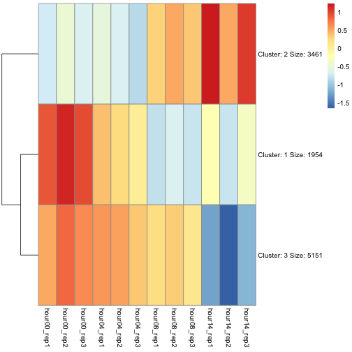

```r
ph3 <- pheatmap(mat = s_clustData,
         kmeans_k = 3,
         cluster_cols = F,
         scale = "none")
```

### How do we figure out the optimal # clusters?

There are many methods, but we will stick with the “elbow” method.

K-means is minimizing the total within cluster sum of squares (wss).

We pick the cluster where that drop in total reaches diminishing returns -> the elbow.

### Functions in R

[figure not shown]

### Our first function

```r
wss <- function(knum, data2clust) {
  ph <- pheatmap(mat = data2clust, kmeans_k = knum, scale = "none", cluster_cols = F, silent = T)
  ph$kmeans$tot.withinss
}
```

### Try function

```r
wss(knum = 2, data2clust = s_clustData)
```

```
[1] 52354.83
```

### Calculate wss for k = 2:10

We need to write a for loop using our fxn wss() that will iterate from k =2 to k = 10.

Then we can see how the wss decreases with more clusters and where the “elbow” is -> our optimal cluster number.

### Combine for loop and function

```r
k2test <- 2:10
clustInfo <- data.frame(k=integer(), wss=double())
set.seed(42)
for (i in k2test) {
  clustInfo[i,1] <- i
  clustInfo[i,2] <- wss(knum = i,data2clust = s_clustData)
}
clustInfo
```

```
    k      wss
1  NA       NA
2   2 52354.83
3   3 45208.64
4   4 39861.42
5   5 36468.10
6   6 34318.07
7   7 33015.73
8   8 31655.88
9   9 30861.09
10 10 29917.57
```

### Find that elbow

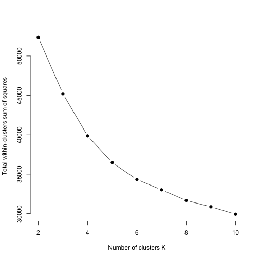

```r
plot(clustInfo$k, clustInfo$wss,
       type="b", pch = 19, frame = FALSE,
       xlab="Number of clusters K",
       ylab="Total within-clusters sum of squares")
```

### Clearly the elbow is at 6 :)

```r
myClust <- pheatmap(mat = s_clustData, kmeans_k = 6, cluster_cols = F, color = viridis(20))
```

[output not shown]

### Join with original data

```r
myClustData <- data.frame(Cluster=myClust$kmeans$cluster,
                gene_symbol=names(myClust$kmeans$cluster)
                )

myHappyData <- left_join(filtData, myClustData, by="gene_symbol") %>% as.data.frame()
```

### 5 minute break

### Part 2: Random sampling

Which cluster contains DUX4 targets?

```r
myClust
```

[output not shown]

### Use GeneOverlap package

```r
# list of genes by dux4 targeting
duxTargetsList <- split(myHappyData$gene_symbol, myHappyData$target)

# list of genes by clustering
geneClustList <- split(myHappyData$gene_symbol, as.factor(myHappyData$Cluster))

# calculate all overlaps between lists
gom.duxClust <- newGOM(duxTargetsList, geneClustList, genome.size = nrow(filtData))

# extract overlaps
duxClust <- getMatrix(gom.duxClust, "intersection")
```

### My money's on...

```r
duxClust <- t(data.frame(duxClust))

duxClust <- duxClust %>% as.tibble %>% mutate(percent = 100*target/(not_target + target), total = not_target + target)

duxClust$clust <- seq(1,6,1)
bestClust <- duxClust %>% arrange(-percent) %>% slice(1L) %>% pull(clust)
```

### Which cluster was that?

```r
myClust
```

[output not shown]

### Is this overlap significant?

We wil learn how to estimate an empirical p-value using [random sampling](https://www.khanacademy.org/math/ap-statistics/tests-significance-ap/idea-significance-tests/v/estimating-p-value-from-simulation).

### Calculate relevant numbers

```r
# fraction of targets in enriched cluster
dux_bestCluster <- myHappyData %>% filter(Cluster==bestClust) %>% group_by(target) %>% tally() %>%  slice(2L) %>% pull(n)
dux_bestCluster
```

```
[1] 37
```

```r
clustSize <- duxClust %>% filter(clust==bestClust) %>% pull(total)

# randomly sample clustSize, # dux targets?
sample_n(tbl = myHappyData, size = clustSize) %>% group_by(target) %>% tally() %>% slice(2L) %>% pull(n)
```

```
[1] 6
```

### For loop time again!

```r
# lets sample 1000 times!
dux_Number <- vector()
for (i in 1:1000) {
dux_Number[i] <- sample_n(tbl = myHappyData, size = clustSize) %>% group_by(target) %>% tally() %>% slice(2L) %>% pull(n)
}

table(dux_Number >= dux_bestCluster)
```

```
FALSE
 1000
```